# Étude de cas

Jules Bernard et Rydch Vincent

Ce jeu de données contient 1108 individus .

### 1. Imputation des données manquantes

L’utilisation de l’ACM, sensible aux valeurs manquantes, peut être difficile en raison de la présence de réponses non renseignées dans notre base de données. Il est donc nécessaire d’imputer ces valeurs manquantes sur la base de l’ACM elle-même (reconstituer à partir de la relation entre modalités). Ainsi, l’idée est de compléter les valeurs manquantes en utilisant la structure des données déjà existantes, sans perdre l’information essentielle.

Après calcul, cette imputation sera basée sur les 3 premières dimensions.

### 2. ACM

Pour l’ACM, nous travaillons sur 1 108 individus et 47 variables, dont 5 variables qualitatives illustratives (l’employeur du sondé, son statut dans l’entreprise, le contrat de travail, la ville de l’emploi, les moyens utilisés pour trouver l’emploi).

### 3. Distribution de l’inertie

L’inertie des axes factoriels indique d’une part si les variables sont structurées et suggère d’autre part le nombre judicieux de composantes principales à étudier.

Les 2 premiers axes de l’ analyse expriment **46.82%** de l’inertie totale du jeu de données ; cela signifie que 46.82% de la variabilité totale du nuage des individus (ou des variables) est représentée dans ce plan. C’est un pourcentage relativement moyen, et le premier plan représente donc seulement une part de la variabilité contenue dans l’ensemble du jeu de données actif. Cette valeur est nettement supérieure à la valeur référence de **9.57%**, la variabilité expliquée par ce plan est donc hautement significative (cette inertie de référence est le quantile 0.95-quantile de la distribution des pourcentages d’inertie obtenue en simulant 594 jeux de données aléatoires de dimensions comparables sur la base d’une distribution uniforme).

Du fait de ces observations, il serait alors probablement nécessaire de considérer également les dimensions supérieures ou égales à la troisième dans l’analyse.

```r
res$eig[1:8,]
```

```
##       eigenvalue percentage of variance cumulative percentage of variance
## dim 1 0.64786476              26.883884                          26.88388
## dim 2 0.48041100              19.935200                          46.81908
## dim 3 0.15317039               6.355979                          53.17506
## dim 4 0.13347743               5.538798                          58.71386
## dim 5 0.10390448               4.311634                          63.02549
## dim 6 0.09575384               3.973414                          66.99891
## dim 7 0.09496098               3.940514                          70.93942
## dim 8 0.09043439               3.752678                          74.69210
```

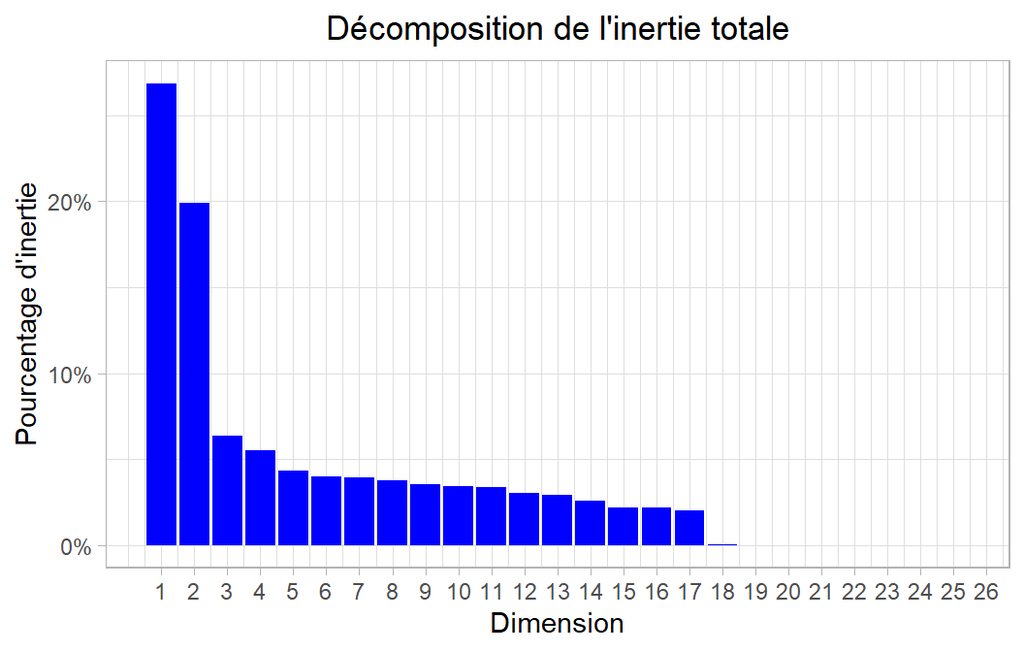

```r
library(ggplot2)
par(mar = c(2.6, 4.1, 1.1, 2.1))
p <- ggplot(cbind.data.frame(x=1:25,y=res.mca$eig[1:25,2])) + aes(x=x, y=y)
p + geom_col(fill="blue") + xlab("Dimension") + ylab("Pourcentage d'inertie") + ggtitle("Décomposition de l'inertie totale") +theme_light() + theme(plot.title = element_text(hjust =0.5)) + scale_x_continuous(breaks=1:nrow(res.mca$eig)) + scale_y_continuous(labels = scales::label_percent(scale = 1))
```

**Figure 3.1- Décomposition de l’inertie totale**

Une estimation du nombre pertinent d’axes à interpréter suggère de restreindre l’analyse à la description des 4 premiers axes. Ces composantes révèlent un taux d’inertie supérieur à celle du quantile 0.95-quantile de distributions aléatoires (58.71% contre 18.5%). Cette observation suggère que seuls ces axes sont porteurs d’une véritable information. En conséquence, la description de l’analyse sera restreinte à ces seuls axes.

### 4. Description du plan 1:2

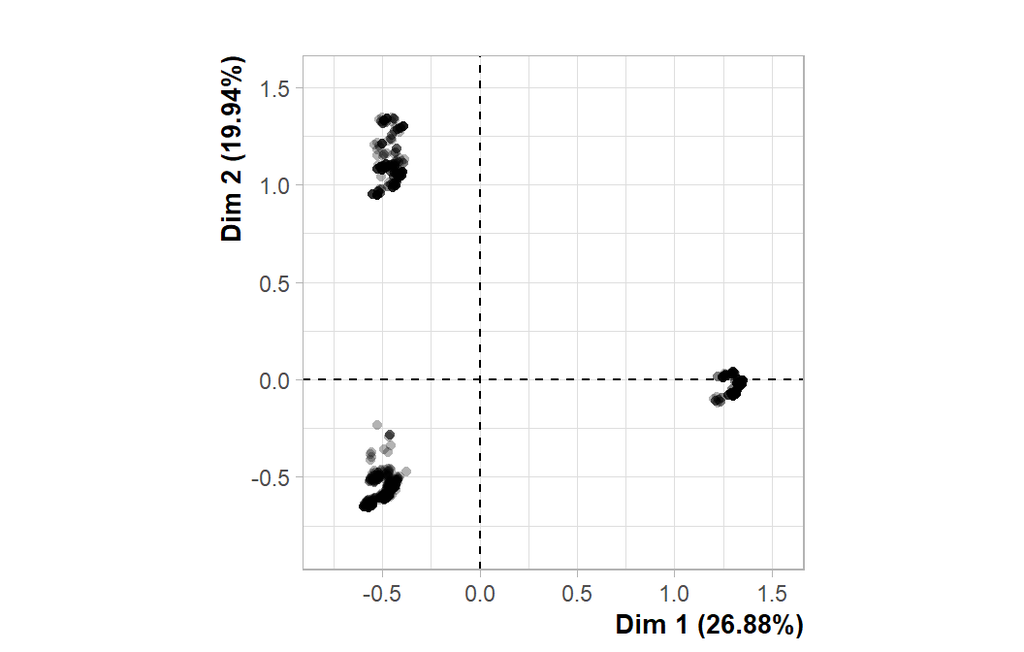

```r
drawn <-
integer(0)
par(mar = c(4.1, 4.1, 1.1, 2.1))
plot.MCA(res.mca, select = drawn, axes = 1:2, choix = 'ind', invisible = c('var', 'quali'), title = '')
```

**Figure 4.1 - Graphe des individus (ACM)**

Dans le cadre d’une Analyse des Correspondances Multiples (ACM), le test de Wilks peut être utilisé pour vérifier si une variable illustrative est significativement associée aux axes factoriels de l’ACM. Cela permet de savoir si une variable supplémentaire (qui n’a pas été utilisée pour construire l’ACM) est liée aux dimensions principales et donc si elle peut être utile pour interpréter les résultats.

```
##                      Ville Statut Employeur Type_contrat Moyen_emploi
## Probabilité critique     0      0         0            0            0
```

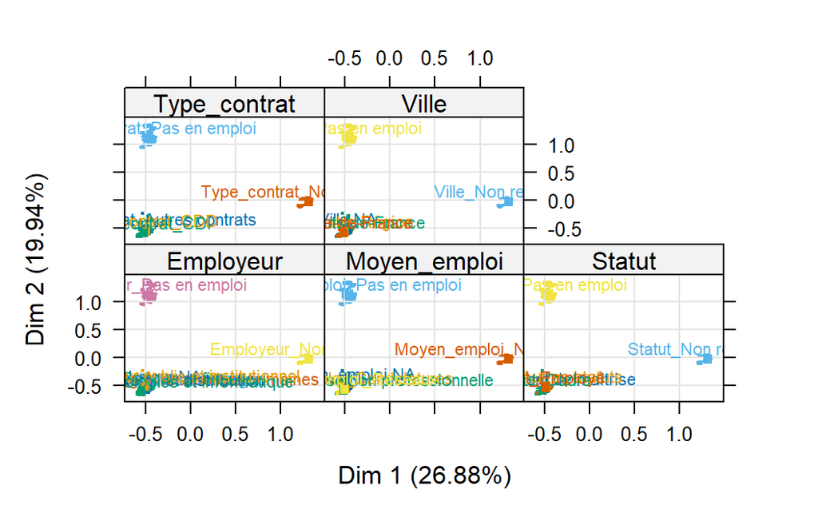

```r
sample = sample(rownames(res.mca$call$X), length(rownames(res.mca$call$X)))
res.mca$call$X = res.mca$call$X[sample,]
res.mca$ind$coord = res.mca$ind$coord[sample[!sample %in% rownames(res.mca$ind.sup$coord)],]
res.mca$ind.sup$coord = res.mca$ind.sup$coord[sample[sample %in% rownames(res.mca$ind.sup$coord)],,drop=FALSE]
drawn <-
integer(0)
hab <-
c("Employeur", "Statut", "Type_contrat", "Ville", "Moyen_emploi"
)
par(mar = c(20, 20, 10, 10))
plotellipses(res.mca, axes = 1:2, invisible = c('var', 'quali'), select = drawn, keepvar = hab, title = '',cex=cex)
```

**Figure 4.2 - Graphe des individus (ACM)** *Les individus libellés sont ceux ayant la plus grande contribution à la construction du plan.* *Les individus sont colorés selon leur appartenance aux modalités*

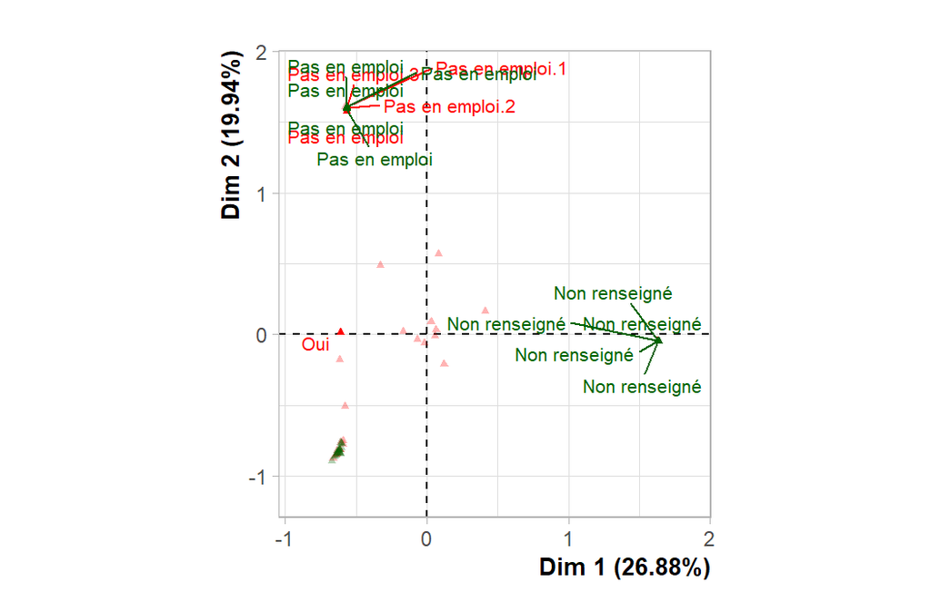

```r
drawn <-
c("Non renseigné", "Non renseigné.1", "Non renseigné.4", "Non renseigné",
"Non renseigné", "Non renseigné.5", "Non renseigné.2", "Non renseigné.3",
"Non", "Non renseigné", "Non renseigné", "Non renseigné",
"Oui", "Pas en emploi", "Pas en emploi.2", "Pas en emploi", "Pas en emploi",
"Pas en emploi.1", "Pas en emploi.3", "Pas en emploi")
par(mar = c(4.1, 4.1, 1.1, 2.1))
plot.MCA(res.mca, selectMod = drawn, axes = c(1,2), choix = 'ind', invisible = 'ind', title = '', cex = cex)
```

**Figure 4.3 - Graphe des variables (ACM)** *Les facteurs en rouges sont les modalités actives, tandis que ceux en vert sont les modalités illustratives.* *Les variables libellées sont celles les mieux représentées sur le plan.*

La **dimension 1** oppose des individus caractérisés par une coordonnée fortement positive sur l’axe (à droite du graphe) à des individus caractérisés par une coordonnée fortement négative sur l’axe (à gauche du graphe).

Du côté droit de l’axe factoriel (caractérisé par une coordonnée positive sur l’axe), on retrouve:

- D’une part, les individus qui n’ont pas répondu à l’enquête et dont les modalités ne sont pas renseignées dans le sondage qui a été réalisé. D’autre part, on retrouve principalement les anciens étudiants issus des mentions EMI et EME classiques. En dehors des mentions, toutes ces modalités sont bien représentées sur l’axe 1 avec un cos² de 0.996 et ont fortement contribué à la création de l’axe.

Du côté gauche de l’axe (caractérisé par une coordonnée négative sur l’axe), on retrouve :

- Les individus qui ont répondu à l’enquête en indiquant qu’ils sont en emploi ou pas du tout.

*Notons que les facteurs Enquete=“Non”, Enquete=“Oui”, Emploi=“Non renseigné” sont extrêmement corrélés à cette dimension (corrélations 0.99, 0.99, 0.99 respectivement). Ces facteurs pourraient donc résumer à eux seuls la dimension 1. On dira donc que cette dernière met en opposition les non-répondants et les répondants de l’enquête.*

La **dimension 2** oppose des individus caractérisés par une coordonnée fortement positive sur l’axe (en haut du graphe) à des individus caractérisés par une coordonnée fortement négative sur l’axe (en bas du graphe).

En haut (caractérisé par une coordonnée positive sur l’axe), on retrouve :

- Les modalités des individus qui ne sont pas en emploi et qui ont effectivement répondu à l’enquête. Une partie d’entre eux est en études. Ces modalités contribuent grandement à la création de l’axe et y sont bien représentées.

En bas (caractérisé par une coordonnée négative sur l’axe), on retrouve :

- Les modalités des individus qui déclarent être en emploi et dont leurs missions sont en accord avec leur formation. Ces individus travaillent généralement en France.

*On peut dire que cette dimension oppose les individus en emploi à ceux qui ne le sont pas.*

### 5. Description du plan 3:4

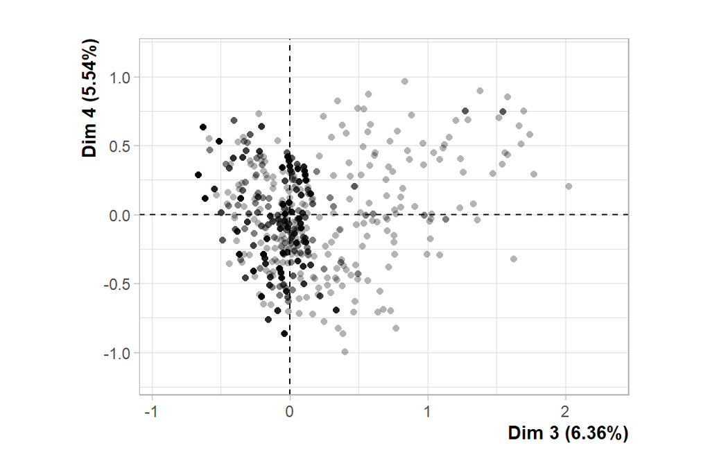

```r
drawn <-
integer(0)
par(mar = c(4.1, 4.1, 1.1, 2.1))
plot.MCA(res.mca, select = drawn, axes = 3:4, choix = 'ind', invisible = c('var', 'quali'), title = '')
```

**Figure 5.1 - Graphe des individus (ACM)** *Les individus libellés sont ceux ayant la plus grande contribution à la construction du plan.*

La probabilité critique du test de Wilks indique la variable dont les modalités sépare au mieux les individus sur le plan (i.e. qui explique au mieux les distances entre individus).

```r
coords <- res.mca$ind$coord[,c('Dim 3','Dim 4')]
Ville <- summary(manova(coords ~eq2$Ville),test="Wilks")$stats[1,6]
Statut<- summary(manova(coords ~eq2$Statut),test="Wilks")$stats[1,6]
Employeur <- summary(manova(coords ~eq2$Employeur),test="Wilks")$stats[1,6]
Type_contrat<- summary(manova(coords ~eq2$Type_contrat),test="Wilks")$stats[1,6]
Moyen_emploi <- summary(manova(coords ~eq2$Moyen_emploi),test="Wilks")$stats[1,6]

data.frame(Ville,Statut,Employeur,Type_contrat,Moyen_emploi,row.names = "Probabilité critique")
```

```
##                          Ville  Statut Employeur Type_contrat Moyen_emploi
## Probabilité critique 0.0261232 0.44552 0.5095543     0.362001    0.6748548
```

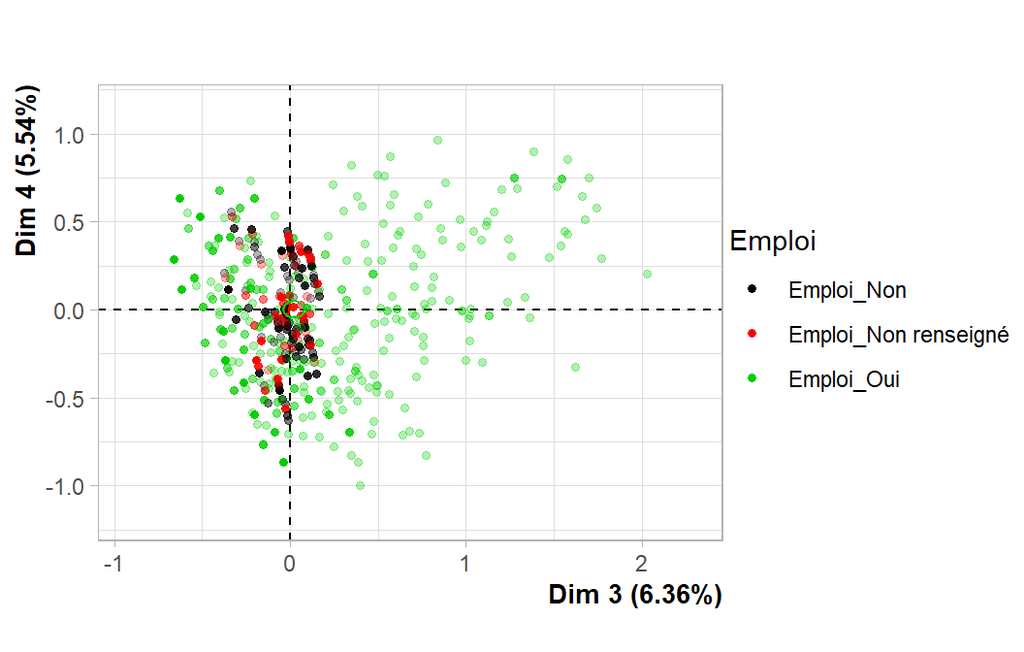

```r
sample = sample(rownames(res.mca$call$X), length(rownames(res.mca$call$X)))
res.mca$call$X = res.mca$call$X[sample,]
res.mca$ind$coord = res.mca$ind$coord[sample[!sample %in% rownames(res.mca$ind.sup$coord)],]
res.mca$ind.sup$coord = res.mca$ind.sup$coord[sample[sample %in% rownames(res.mca$ind.sup$coord)],,drop=FALSE]
drawn <-
integer(0)
hab <-
"Emploi"
par(mar = c(4.1, 4.1, 1.1, 2.1))
plotellipses(res.mca, axes = 3:4, invisible = c('var', 'quali'), select = drawn, keepvar = hab, title = '' )
```

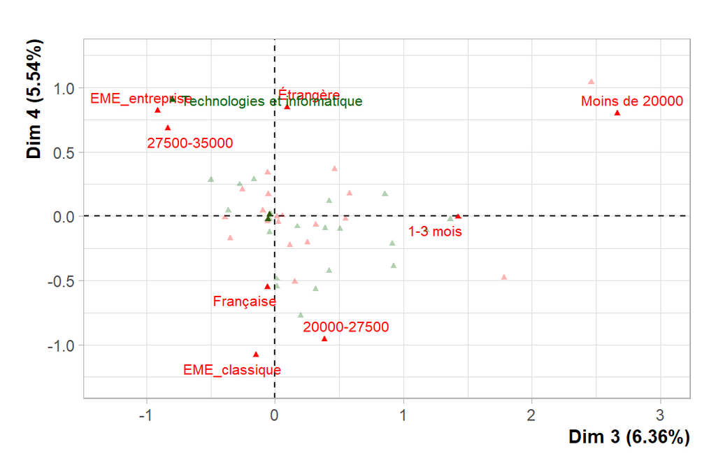

```r
drawn <-
c("Travail_France_Non.", "Française", "Étrangère", "EME_classique", "Moins de 20000",
"EME_entreprise", "27500-35000", "20000-27500", "Technologies et informatique",
"1-3 mois")
par(mar = c(4.1, 4.1, 1.1, 2.1))
plot.MCA(res, selectMod = drawn, axes = c(3,4), choix = 'ind', invisible = 'ind', title = '', cex = cex)
```

**Figure 5.3 - Graphe des variables (ACM)** *Les facteurs en rouges sont les modalités actives, tandis que ceux en vert sont les modalités illustratives.* *Les variables libellées sont celles les mieux représentées sur le plan.*

La **dimension 3** oppose des individus caractérisés par une coordonnée fortement positive sur l’axe (à droite du graphe) à des individus caractérisés par une coordonnée fortement négative sur l’axe (à gauche du graphe).

Du coté droit (caractérisés par une coordonnée positive sur l’axe) on retrouve :

- Les modalités de ceux qui travaillent à l’étranger, qui ont un salaire de moins de 20 000, qui ont un travail n’ayant pas de rapport avec leurs études et qui ont mis plus d’un mois pour trouver un travail. Ces modalités sont les mieux représentées et contribuent beaucoup à la formation de l’axe. Dans cette partie, on retrouve surtout des femmes et des individus des mentions EMP, EMI et EA, bien que ces modalités, étant moins bien représentées, ne contribuent pas fortement à la création de l’axe.

Du côté gauche (caractérisés par une coordonnée négative sur l’axe) on retrouve :

- Les modalités des individus des mentions EME (OGC, SIAD) et EME classique, qui travaillent en France, gagnent un salaire entre 27 500 et 35 000 et sont surtout des hommes ayant répondu à l’enquête.

*On peut dire que cet axe oppose le lieu de travail mais aussi les différentes mentions de l’ISEM.*

La **dimension 4** oppose des individus caractérisés par une coordonnée fortement positive sur l’axe (en haut du graphe) à des individus caractérisés par une coordonnée fortement négative sur l’axe (en bas du graphe).

En haut (caractérisé par une coordonnée positive sur l’axe) on retrouve:

- Les individus de nationalité étrangère, les anciens étudiants de la filière EME (OGC, SIAD) et les individus plus âgés, qui contribuent le plus à la création de l’axe.

Du côté négatif (caractérisés par une coordonnée négative sur l’axe) on retrouve:

- Les individus issus de la filière EME classique, ceux de nationalité française, ainsi que les individus les plus jeunes qui contribuent à la création de l’axe.

*Cet axe oppose les deux fillières EME , l’âge et la nationalité.*

### 6. Classification

```r
res.hcpc <- HCPC(res.mca, graph = FALSE)
```

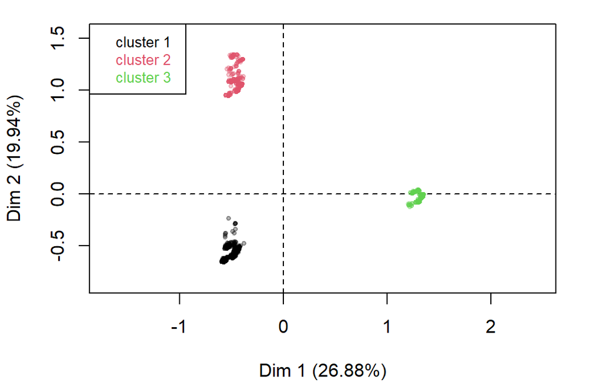

```r
drawn <-
integer(0)
par(mar = c(4.1, 4.1, 1.1, 2.1))
plot.HCPC(res.hcpc, choice = 'map', draw.tree = FALSE, select = drawn, title = '')
```

**Figure 6 - Classification Ascendante Hiérachique des individus.** *La classification réalisée sur les individus fait apparaître 3 clusters.*

La classe 1

La classe 2

- Le reste des 282 sondés se retrouve dans cette classe caractérisée par ceux n’ayant pas encore trouvé un emploi ou en poursuite d’étude. De tout le sondage, 45% des étudiants de la mention Economie appliquée (EA) et 44% en Economie management publique (EMP) sont représentés dans la deuxième classe.

La classe 3 :

- Cette classe regroupe les individus qui n’ont pas répondu à l’enquête. En ce qui concerne la répartition des mentions, les individus se répartissent de la manière suivante : 14 % des étudiants en EA, 43 % des étudiants en EMI, et 32 % des étudiants en EME classique. Par ailleurs, le pourcentage d’hommes et le pourcentage de Français dans cette classe s’élèvent à 24 %. Ces deux modalités sont donc sous-représentées dans la classe 3.